# lpirfs: An R Package to Estimate Impulse Response Functions by Local Projections

Impulse response analysis is a cornerstone in applied (macro-)econometrics. Estimating impulse response functions using local projections (LPs) has become an appealing alternative to the traditional structural vector autoregressive (SVAR) approach. Despite its growing popularity and applications, however, no R package yet exists that makes this method available. In this paper, I introduce *lpirfs*, a fast and flexible R package that provides a broad framework to compute and visualize impulse response functions using LPs for a variety of data sets.

Philipp Adämmer (Department of Mathematics and Statistics, Helmut Schmidt University)  
2019-12-27

## 1 Introduction

Since the seminal paper of (Sims 1980), analysing economic time series by Vector Auto Regressive (VAR) models has become a main pillar in empirical macroeconomic analysis. VARs have been traditionally used to recover structural shocks in order to estimate their propagating effects on economic variables. This approach, however, has been criticized for several drawbacks such as the imposed dynamics on the (economic) system, the curse of dimensionality and the more difficult application to nonlinearities (Auerbach and Gorodnichenko 2013).

Estimating impulse response functions using local projections (LPs) has become an appealing alternative, which is reflected in the over 1,000 citations of the pioneering paper by (Jordà 2005). Instead of extrapolating the parameters into increasingly distant horizons, LPs estimate the parameters sequentially at each point of interest. It is argued that LPs offer three advantages over the traditional structural vector autoregressive (SVAR) approach: first, LPs are easier to estimate since they rely solely on simple linear regressions; second, the point or joint-wise inference is easily conducted; and third, impulse responses that are estimated using LPs are more robust when a (linear) VAR is misspecified (Jordà 2005). Although the latter argument has been questioned by (Kilian and Kim 2011), the recent study by (Brugnolini 2018) shows equal and even better performance of LPs when the lag lengths for each forecast horizon are adequately fixed. Yet, (Plagborg-Møller and Wolf 2019) proved that LPs and VAR models estimate the same impulse responses when the lag structures are unrestricted. This finding implies that empirical impulse responses that are estimated using LPs and SVARs are likely similar at short horizons but differ at longer ones.[^1]

Since their introduction in 2005, LPs have been broadly applied to investigate, among others, the macroeconomic effects of oil price shocks (Hamilton 2011); state-dependent government spending multipliers (Auerbach and Gorodnichenko 2012; Auerbach and Gorodnichenko 2013; Owyang et al. 2013); the effects of monetary policy on financial markets and economic aggregates (Tenreyro and Thwaites 2016; Swanson 2017; Jordà et al. 2019); and the link between credit growth, monetary policy, house prices, and financial stability (Favara and Imbs 2015; Jordà et al. 2015; Jordà and Taylor 2016). Apart from the different research questions, these studies further differ regarding the data structures because they use panel and nonpanel data.

Despite the rising popularity and applications, no R package yet exists that can estimate impulse responses using LPs. The only exception is the code for the smooth LP approach by (Barnichon and Brownlees 2019). The approach reduces the variance of the LP parameters with a linear B-spline basis function because LP coefficients can suffer from high variance, sometimes making the interpretation more difficult. The code is partly available on [GitHub](https://github.com/ctbrownlees/R-Package-lproj) and has been applied by (Garı́n et al. 2019). The [*vars*](https://CRAN.R-project.org/package=vars) package by (Pfaff 2008) only allows estimating impulse response functions that are based on the traditional SVAR approach.

As a remedy, this paper introduces [*lpirfs*](https://CRAN.R-project.org/package=lpirfs) (Adämmer 2019), a fast and flexible R package that enables estimating and visualizing impulse responses using LPs for a variety of data sets. The first part of this paper outlines the theory of LPs and the differences from the traditional SVAR approach. The second part outlines the main functions and options of the package, and the last section applies *lpirfs* by replicating the empirical results from the economic literature.

## 2 Estimating impulse response functions using local projections

An SVAR with $n$ variables can be written as follows:

$$\begin{aligned}
\label{VAR_struct} \nonumber
\begin{pmatrix}
\beta_{11}^0 & \dots & \beta_{1n}^{0}\\ \vdots & \ddots & \vdots \\ \beta_{n1}^0 & \dots & \beta_{nn}^0 \end{pmatrix}
\begin{pmatrix}
y_1 \\ \vdots \\ y_n \end{pmatrix}_{t}
=
&\begin{pmatrix}
\alpha_1 \\ \vdots \\ \alpha_n \end{pmatrix} +
\begin{pmatrix}
\beta_{11}^1 & \dots & \beta_{1n}^{1}\\ \vdots & \ddots & \vdots \\ \beta_{n1}^1 & \dots & \beta_{nn}^1 \end{pmatrix}
\begin{pmatrix}
y_1 \\ \vdots \\ y_n \end{pmatrix}_{t-1} + \dots + \\
&\begin{pmatrix}
\beta_{11}^p & \dots & \beta_{1n}^{p}\\ \vdots & \ddots & \vdots \\ \beta_{n1}^p & \dots & \beta_{nn}^p \end{pmatrix}
\begin{pmatrix}
y_1 \\ \vdots \\ y_n \end{pmatrix}_{t-p} +
\begin{pmatrix}
\varepsilon_1 \\ \vdots \\ \varepsilon_n \end{pmatrix}_{t}, \nonumber
\end{aligned} \tag{1}$$

which more concisely becomes the following:

$$\nonumber
\mathbf{B_0} \mathbf{Y}_t = \boldsymbol{\alpha}_t + \mathbf{B(L)} \mathbf{Y}_t + \boldsymbol{\varepsilon}_t.$$

The residuals $\boldsymbol{\varepsilon}_t$ are assumed to be white noise with zero mean.[^2] This representation is appealing from an economic perspective because the structural shocks are contemporaneously uncorrelated, and the variables have a contemporaneous effect on each other. The contemporaneous effect is measured by the square matrix $\mathbf{B_0}$. However, estimating this SVAR without further assumptions is not possible because of the simultaneous identification problem. Merely assuming that the structural shocks are orthogonal does not fully identify the system.

The SVAR in reduced form (henceforth VAR) equals:
$$\label{reduced_VAR} \nonumber
\mathbf{Y}_t = \boldsymbol{\tilde{\alpha}} + \boldsymbol{\tilde{B}(L)} \mathbf{Y}_t + \boldsymbol{u}_t, \tag{2}$$

where
$$\boldsymbol{\tilde{\alpha}} = \mathbf{B_0}^{-1}\boldsymbol{\alpha}, \ \boldsymbol{\tilde{B}(L)} = \mathbf{B_0}^{-1} \mathbf{B(L)}$$
and
$$E[\boldsymbol{u}_t, \boldsymbol{u}_\tau^{'} ]= \left\{ \begin{array}{l@{\quad \quad}l}
\begin{pmatrix}
\sigma_{1}^2 & \dots & \sigma_{1,n}^2 \\ \vdots & \ddots & \vdots \\ \sigma_{n,1} & \dots & \sigma_{n}^2 \end{pmatrix} ,& for \ \ t = \tau
\\ \ 0, & else.
\end{array} \right.$$

The coefficient matrix $\boldsymbol{\tilde{B}(L)}$ is a nonlinear function of the contemporaneous parameter matrix $\mathbf{B_0}$ and the structural parameter matrix $\boldsymbol{B(L)}$. In contrast to the SVAR, the VAR residuals $\boldsymbol{u}_t$ are contemporaneously correlated, which impedes an unbiased economic interpretation. The VAR residuals are assumed to be linked to the SVAR shocks by the following:

$$\mathbf{u_t} = \mathbf{B_0}^{-1}\boldsymbol{\varepsilon_t}, \quad \quad E[\mathbf{u_t u_t^{'}} ] = \mathsf{\Sigma}_\mathbf{u} = \mathbf{B_0}^{-1} \mathbf{B_0}^{-1'}.$$

Given that the covariance matrix of $\boldsymbol{\varepsilon}_t$ equals the identity matrix, one must still impose $n(n-1)/2$ restrictions to estimate the structural form. The most general approach is to separate the residuals into orthogonal shocks by calculating a Cholesky decomposition of the covariance matrix $\mathsf{\Sigma}_u$. The first variable in such a system responds to its own exogenous shock, the second variable to the first variable plus an exogenous shock to the second variable, and so on. The results thus depend on ordering (Keating 1992). The Wold representation states that any covariance-stationary time series can be rewritten as a sum of present and past innovations. This theorem enables mapping the estimated VAR($p$) coefficients recursively to the infinite-order vector moving-average coefficients (Brugnolini 2018). Impulse response functions are estimated iteratively by rewriting VAR($p$) into its companion form (i.e., a VAR(1)):

$$\begin{aligned}
\nonumber
\hat{IR}(0) &= \mathbf{B_0}^{-1} \\ \nonumber
\hat{IR}(1) &= \boldsymbol{\Phi^{1}} \mathbf{B_0}^{-1} \\ \nonumber
\hat{IR}(2) &= \boldsymbol{\Phi^{2}} \mathbf{B_0}^{-1} \\ \nonumber
\vdots \ \ ,
\end{aligned}$$

where the matrix $\boldsymbol{\Phi}$ contains the coefficients of the VAR(1).

In his pioneering paper, (Jordà 2005) proposed an alternative approach to estimate impulse responses. His first step consists of ordinary least squares (OLS) regressions for each forecast horizon:

$$\label{eq_lp}
\mathbf{y}_{t+h} = \boldsymbol{\alpha}^h + \mathbf{B}_1^h \mathbf{{y}}_{t-1} + \dots + \mathbf{B}_p^{h} \mathbf{{y}}_{t-p} + \mathbf{u}_{t+h}^h, \quad h = 0,1, \ \dots \ ,H-1, \tag{3}$$

where $\boldsymbol{\alpha}^h$ is a vector of constants, and $\mathbf{B}_i^h$ are parameter matrices for lag $p$ and forecast horizon $h$. The vector elements $\mathbf{u}_{t+h}^h$ are autocorrelated and/or heteroscedastic disturbances. The collection of all regressions of Eq. ((3)) are called LPs. The slope matrix $\mathbf{B}_1^h$ can be interpreted as the response of $\mathbf{y}_{t+h}$ to a reduced form shock in $t$ (Kilian and Kim 2011). Structural impulse responses are then estimated by the following:

$$\label{eq_lp_ir}
\hat{IR}(t, h, \mathbf{d}_i) = \mathbf{\hat{B}}_1^h\mathbf{d}_i, \tag{4}$$

where $\mathbf{d}_i = \mathbf{B}_0^{-1}.$ As in the SVAR approach, the shock matrix $\mathbf{d}_i$ must be identified from a linear VAR. The LP approach thus does not overcome the problem of identification. Given the serial correlation of $\mathbf{u}_{t+h}^h$, (Jordà 2005) proposed to estimate robust standard errors using the approach by (Newey and West 1987).

A great advantage of LPs is their easy extension to nonlinear frameworks. The simplest approach to separate data into two regimes is using a binary (dummy) variable. The drawback, however, is that it lowers the degrees of freedom. As a remedy, (Auerbach and Gorodnichenko 2012) proposed computing state probabilities with a logistic function that allows using all observations for the estimations. The logistic function equals the following:

$$\begin{aligned}
F({z_t}) & = \ \frac{e^{(-\gamma z_t)}}{\left(1 + e^{(-\gamma z_t)}\right)}, \label{switching_variable_1} \\
\end{aligned} \tag{5}$$

$$\begin{aligned}
var(z_t) & = 1, \ E(z_t) = 0, \label{switching_variable_2}
\end{aligned} \tag{6}$$

where $z_t$ is standardized so that $\gamma$ (> 0) is scale-invariant. The value of $\gamma$ must be provided by the user. For example, if $z_t$ corresponds to changes in the gross domestic product (GDP) at time $t$, an increase in $z_t$ would lead to a decrease in $F(z_t)$. Values close to zero of $F(z_t)$ would thus indicate periods of economic expansion. (Auerbach and Gorodnichenko 2013) proposed standardizing the cyclical components of the filter according to the method by (Hodrick and Prescott 1997) to obtain the variable $z_t$. The observations for the two regimes are the product of the transition function and the endogenous variables:

$$\begin{aligned}
\label{regime_values}
\begin{aligned}
\text{Regime 1} \ (R_1) &: \mathbf{y}_{t-l}\cdot(1-F(z_{t-1})), \qquad l = 1, \ \dots \ , p, \\
\text{Regime 2} \ (R_2) &:\mathbf{y}_{t-l}\cdot F(z_{t-1}), \hskip 4.5em l = 1, \ \dots \ , p.
\end{aligned}
\end{aligned} \tag{7}$$

(Auerbach and Gorodnichenko 2012) used the values of the transition function at $t-1$ to avoid contemporaneous feedback from policy actions regarding whether the economy is in a recession or an expansion. Structural nonlinear impulse responses are estimated using the following:

$$\begin{aligned}
\nonumber
\hat{IR}^{R_1}(t,h,\mathbf{d}_i) & = \hat{\mathbf{B}}_{1, R_1}^h \mathbf{d}_i, \ \ \ \ \ \ \ \ \ h = 0, \ \dots \ , H-1, \\ \nonumber
\hat{IR}^{R_2}(t,h,\mathbf{d}_i) & = \hat{\mathbf{B}}_{1, R_2}^h \mathbf{d}_i, \ \ \ \ \ \ \ \ \ h = 0, \ \dots \ , H-1,
\end{aligned}$$

where $\hat{\mathbf{B}}_{1, R1}^0 = I$ and $\hat{\mathbf{B}}_{1, R2}^0 = I$. The coefficient matrices $\hat{\mathbf{B}}_{1, R_1}^h$ and $\hat{\mathbf{B}}_{1, R_2}^h$ are obtained from the following LPs:

$$\begin{aligned}
\label{nonlinear_lp}
\begin{aligned}
\mathbf{y}_{t+h} = \boldsymbol{\alpha}^h \ + & \ \mathbf{B}_{1, R_1}^{h} \left(\mathbf{y}_{t-1}\cdot(1-F(z_{t-1})\right) \ + \ \dots \ +\
\mathbf{B}_{p, R_1}^{h} \left(\mathbf{y}_{t-p}\cdot(1-F(z_{t-1})\right) + \\
& \ \mathbf{B}_{1, R_2}^{h} \left(\mathbf{y}_{t-1}\cdot F(z_{t-1}\right)) \ \ \quad \quad + \ \dots \ + \ \mathbf{B}_{p, R_2}^{h} \left(\boldsymbol{y}_{t-p}\cdot F(z_{t-1}\right)) \quad \quad + \ \mathbf{u}_{t+h}^h,
\end{aligned}
\end{aligned} \tag{8}$$

with $h = 0, \ \dots \ , H-1.$ This nonlinear approach has been used by (Ahmed and Cassou 2016) to investigate the effect of consumer confidence on durable goods during periods of economic expansion and recession.

### 2.1 Estimating impulse responses with an identified shock

Besides the easy extension to nonlinear frameworks, another advantage of LPs is their flexible application to situations in which an exogenous shock can be identified outside of an SVAR. For example, (Ramey and Zubairy 2018) constructed a military news shock to investigate whether US government spending multipliers are higher during periods of economic slack or when interest rates are near the zero lower bound. Once an exogenous shock has been identified, impulse responses can be directly estimated using OLS regressions:

$$\label{eq_lp_lin_iv}
y_{t+h} = \alpha^h + \beta_h shock_t + \phi x_{t} + u_{t+h}^h, \quad h = 0,1, \ \dots \ ,H-1, \tag{9}$$

where $\alpha^h$ denotes the regression constant, $x_{t}$ is a vector of control variables, and $shock_t$ is the identified shock variable. The coefficient $\beta_h$ corresponds to the response of $y$ at time $t + h$ to the shock variable ($shock$) at time $t$. The impulse responses are the sequence of all estimated $\beta_h$. As above, robust standard errors can be estimated using the approach by (Newey and West 1987). If the shock variable is endogenous, $shock_t$ can be estimated using the two-stage least squares (2SLS) regression. In the case of nonlinearities, the variables can either be multiplied with a dummy variable or with the values of the transition function in Eq. ((7)).

### 2.2 Estimating impulse responses for panel data

Another advantage of LPs is that they can be applied to panel data as well. Estimating impulse responses based on panel data have been put forward by (Auerbach and Gorodnichenko 2013), (Owyang et al. 2013), and (Jordà et al. 2015), among others. The general equation for panel data is the following:

$$\nonumber
y_{i,t+h} = \alpha_{i,h} + shock_{i,t}\beta_h + {x}_{i,t}\boldsymbol{\gamma}_h + \varepsilon_{i, t + h}, \quad h = 0,1, \ \dots \ ,H-1,$$

where $\alpha_{i, h}$ denotes (cross-section) fixed effect, ${x}_{i,t}$ is a vector of control variables, and $shock_{i,t}$ denotes the identified shock variable. Besides using the absolute values of $y_t$, *lpirfs* also allows estimating cumulative impulse responses using ($y_{i,t+h} - y_{i,t-1}$) as the endogenous variable, which is often done for panel data (see, e.g., (Jordà et al. 2015)). Similar to the univariate approach, $shock_t$ can also be first estimated by an instrument variable approach (see, e.g., (Jordà et al. 2019)). It is further crucial to account for heteroskedasticity and autocorrelation in panel models. The importance of robust standard errors in the context of corporate finance and asset pricing has been shown by (Petersen 2009).

## 3 The *lpirfs* package

*lpirfs* enables estimating all of the above models and specifications. The main functions of the package are the following:

- `lp_lin()` and `lp_nl()`, which estimate linear and nonlinear impulse responses based on structural VARs,
- `lp_lin_iv()` and `lp_nl_iv()`, which estimate linear and nonlinear impulse responses for a shock that has been identified outside of the VAR, and
- `lp_lin_panel()` and `lp_nl_panel()`, which estimate linear and nonlinear impulse responses for panel data.

The functions `lp_lin()` and `lp_nl()` estimate linear and nonlinear impulse responses based on SVARs whose shocks are identified by the Cholesky decomposition. The functions `lp_lin_iv()` and `lp_nl_iv()` allow estimating impulse responses when a shock has been identified outside of the VAR. The functions `lp_lin_panel()` and `lp_nl_panel()` can be used for panel data.

Nonpanel functions rely on several routines written with [*Rcpp*](https://CRAN.R-project.org/package=Rcpp) by (Eddelbuettel et al. 2011), making the computations very fast. The functions for panel data are based on the well-established [*plm*](https://CRAN.R-project.org/package=plm) package by (Croissant and Millo 2008). Parallel computation, which is optional and available for all functions, can further reduce the computation time.

Nonpanel functions allow computing ordinary and heteroskedasticity and autocorrelation consistent (HAC) estimators for the impulse responses based on the approach by (Newey and West 1987). By default, *lpirfs* increases the truncation parameter with the number of horizons $h$, but a fixed value can also be manually provided. In addition, pre-whitening is another option that might improve the confidence interval coverage (Andrews and Monahan 1992). The user can also apply an information criterion for each forecast horizon to find the optimal number of lags. The included criteria are those developed by (Akaike 1974), (Schwarz 1978), and (Hurvich and Tsai 1989). The endogenous, exogenous, and switching variables must be given separately as a `data.frame`. Table 1 summarizes the input options of the nonpanel functions.

Applying *lpirfs* to panel data works slightly differently than using nonpanel functions due to the dependency on the *plm* package. Instead of providing the endogenous and exogenous variables separately, the user must provide the entire panel data set first, and then give the column names for the endogenous, exogenous, and other variables. The default is to estimate a fixed-effects model, but all options available for the *plm* package are also available within *lpirfs*. Table 2 summarizes the input options for the linear and nonlinear panel functions.

Each function output becomes an S3 object, which enables using the generic R functions `plot()` and `summary()`. In addition, the package also contains the functions `plot_lin()` and `plot_nl()`, which enable creating individual graphs of impulse responses.

Table 1: Comparison of linear and nonlinear LP functions.

|  | Function names |  |  |  |  |
| --- | --- | --- | --- | --- | --- |
| Input name | `lp_lin()` | `lp_nl()` | `lp_lin_iv()` | `lp_nl_iv()` | Input description |
| endog_data | $\checkmark$ | $\checkmark$ | $\checkmark$ | $\checkmark$ | Data.frame with endogenous variables for VAR model. |
| shock | - | - | $\checkmark$ | $\checkmark$ | One column data.frame with the identified shock. |
| use_twosls | - | - | $\checkmark$ | - | Option to estimate shock with 2SLS approach. |
| instrum | - | - | $\checkmark$ | - | Data.frame with the instrument(s) for the 2SLS approach. |
| lags_endog_lin | $\checkmark$ | $\checkmark$ | $\checkmark$ | - | Number of lags for linear model. |
| lags_endog_nl | - | $\checkmark$ | - | $\checkmark$ | Number of lags for nonlinear model in Eq. ((8)). |
| lags_criterion | $\checkmark$ | $\checkmark$ | $\checkmark$ | $\checkmark$ | Choose lags based on information criterion (*AICc, AIC* or *BIC*). |
| max_lags | $\checkmark$ | $\checkmark$ | $\checkmark$ | $\checkmark$ | Maximum number of lags for information criterion. |
| trend | $\checkmark$ | $\checkmark$ | $\checkmark$ | $\checkmark$ | Options to include constant, trend and quadratic trend. |
| shock_type | $\checkmark$ | $\checkmark$ | - | - | Two types of shock: standard deviation or unit shock. |
| use_nw | $\checkmark$ | $\checkmark$ | $\checkmark$ | $\checkmark$ | Option to estimate standard errors by (Newey and West 1987). |
| nw_lag | $\checkmark$ | $\checkmark$ | $\checkmark$ | $\checkmark$ | Option to manually fix the truncation parameter. |
| nw_prewhite | $\checkmark$ | $\checkmark$ | $\checkmark$ | $\checkmark$ | Option for pre-whitening (Andrews and Monahan 1992). |
| adjust_se | $\checkmark$ | $\checkmark$ | $\checkmark$ | $\checkmark$ | Option to adjust standard errors for small samples. |
| confint | $\checkmark$ | $\checkmark$ | $\checkmark$ | $\checkmark$ | Value of width for confidence bands. |
| hor | $\checkmark$ | $\checkmark$ | $\checkmark$ | $\checkmark$ | Number of horizons for impulse responses. |
| switching | - | $\checkmark$ | - | $\checkmark$ | Switching variable $z_t$. See Eq. (5). |
| lag_switching | - | $\checkmark$ | - | $\checkmark$ | Option to lag the values of the logistic function $F(z_t)$. |
| use_logistic | - | $\checkmark$ | - | $\checkmark$ | Option to use the logistic function. See Eq. (5). |
| use_hp | - | $\checkmark$ | - | $\checkmark$ | Option to use the filter by (Hodrick and Prescott 1997). |
| lambda | - | $\checkmark$ | - | $\checkmark$ | Value of $\lambda$ for the HP-filter. See (Ravn and Uhlig 2002). |
| gamma | - | $\checkmark$ | - | $\checkmark$ | Value of $\gamma$. See Eq. ((5)). |
| exog_data | $\checkmark$ | $\checkmark$ | $\checkmark$ | $\checkmark$ | Optional data for exogenous variables. |
| lags_exog | $\checkmark$ | $\checkmark$ | $\checkmark$ | $\checkmark$ | Number of lags for exogenous variables. |
| contemp_data | $\checkmark$ | $\checkmark$ | $\checkmark$ | $\checkmark$ | Variables with contemporaneous impact. |
| num_cores | $\checkmark$ | $\checkmark$ | $\checkmark$ | $\checkmark$ | Option to choose number of cores. |

The table compares the options for `lp_lin()`, `lp_nl()`, `lp_lin_iv()`, and `lp_nl_iv()`. The symbol $\checkmark$ indicates whether the option, denoted by the row, is available for the function, denoted by the column. The optional lag length criteria are those by (Hurvich and Tsai 1989), (Akaike 1974) and (Schwarz 1978).

Table 2: Comparison of linear and nonlinear LP functions for panel data.

[output not shown]

The table compares the options for `lp_lin_panel()` and `lp_nl_panel()`. The symbol $\checkmark$ indicates whether the option, denoted by the row, is available for the function, denoted by the column. The functions estimate linear and nonlinear impulse responses for models with panel data.

## 4 Examples and replications

In this section, I apply all the main functions of *lpirfs* to three different settings. The impulse responses are visualized by the generic `plot()` function, which serves as a wrapper for the built-in functions `plot_lin()` and `plot_nl()`.

Two exercises replicate empirical results by (Jordà 2005) and (Ramey and Zubairy 2018). The data sets are included in *lpirfs*. The third example uses the external *Jordà-Schularick-Taylor Macrohistory Database*, which covers 17 advanced economies since 1870 on an annual basis and comprises 25 real and nominal variables. I estimate how an increase in the interest rate affects mortgage lending. This example is based on a STATA code provided on Oscar Jordá’s [website](https://sites.google.com/site/oscarjorda/home/local-projections). Due to copyright issues, the database could not be included in the package, but I show how it can be easily downloaded with R.

### 4.1 Traditional approach: Replicating results by Jordà (2005)

The following code replicates parts of Figure 5 in Jordà (2005 176). It shows how the output gap, inflation rate, and federal funds rate react to the corresponding structural shocks. The results are shown in Figure 1.[^3] *lpirfs* follows the convention by (Jordà 2005), namely that the first horizon, denoted on the $x$-axis, equals $h = 0$. Applying the generic function `summary()` to the output returns a list of several matrices with OLS diagnostics. The first level of the list corresponds to the shock variable and the second level to the horizon. Table 3 shows OLS diagnostics for the first horizon of the first shock (output gap).

```r
# --- Code to replicate Figure 5 in Jordá (2005, p. 176)

# Load packages
  library(lpirfs)

# Load data set
  endog_data  <- interest_rules_var_data

# Estimate linear model
  results_lin <- lp_lin(endog_data     = endog_data,
                        lags_endog_lin = 4,
                        trend          = 0,
                        shock_type     = 1,
                        confint        = 1.96,
                        hor            = 12)

# Show impulse responses
  plot(results_lin)

# Show OLS diagnostics for the first shock of the first horizon
  summary(results_lin)[[1]][1]


# --- End example code
```

Table 3: OLS diagnostics shown by using `summary()`.

|  | R.sqrd. | Adj. R.sqrd. | F.stat | p.value |
| --- | --- | --- | --- | --- |
| h 1: GDP_gap | 0.91 | 0.90 | 146.88 | 0.00 |
| h 1: Infl | 0.84 | 0.83 | 77.17 | 0.00 |
| h 1: FF | 0.94 | 0.93 | 218.74 | 0.00 |

The table shows OLS diagnostics for the (Jordà 2005) example of the first horizon for the first identified shock (output gap).

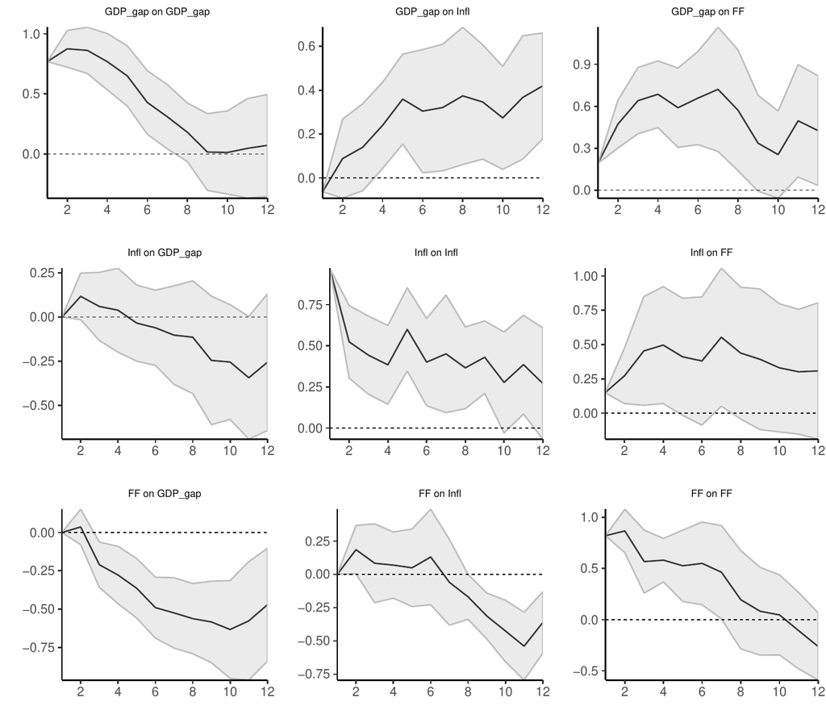

Figure 1: Replication of Figure 5 in Jordà (2005 176).

The example above only estimates impulse responses for the linear case, but (Jordà 2005) also tested for nonlinearities. Although he found no “business-cycle” asymmetries, he identified significant asymmetries for several lags of both inflation and the federal funds rate. The following code uses a dummy approach to estimate the nonlinear impulse responses of the variables to a shock in the federal funds rate. (Jordà 2005) used a threshold of 4.75% for the inflation rate, applied to its third lag. Figure 2 shows the empirical results for the nonlinear example. The results are comparable to the findings by (Jordà 2005), namely that the magnitudes of responses of inflation and output to interest rates are more responsive in the low-inflation regime (left panel) than in the high-inflation regime (right panel).

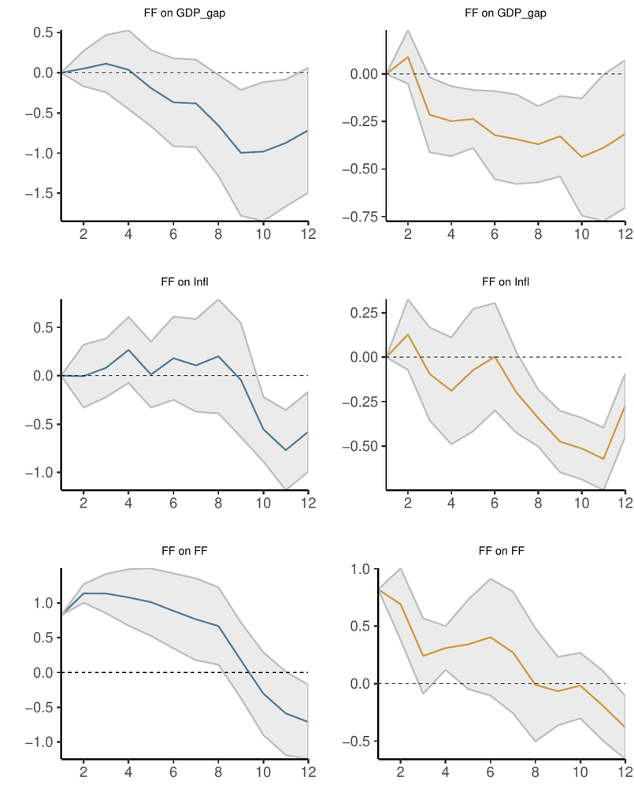

Figure 2: Nonlinear impulse responses based on (Jordà 2005).

```r
# --- Code for nonlinear effects of the federal funds rate.

# Load packages for creating plots
  library(dplyr)
  library(gridExtra)
  library(ggpubr)

# Create dummy: apply threshold of 4.75 percent to the third lag of the inflation rate
  switching_data <-  if_else(dplyr::lag(endog_data$Infl, 3) > 4.75, 1, 0)

# Estimate nonlinear model
  results_nl <- lp_nl(endog_data,
                       lags_endog_lin = 4,              lags_endog_nl = 4,
                       trend          = 1,              shock_type    = 0,
                       confint        = 1.67,           hor           = 12,
                       switching      = switching_data, lag_switching = FALSE,
                       use_logistic   = FALSE)

# Create nonlinear impulse responses
  nl_plots <- plot_nl(results_nl)

# Combine and show plots using 'ggpubr' and 'gridExtra'
  single_plots      <- nl_plots$gg_s1[c(3, 6, 9)]
  single_plots[4:6] <- nl_plots$gg_s2[c(3, 6, 9)]
  all_plots         <- sapply(single_plots, ggplotGrob)
  marrangeGrob(all_plots, nrow = 3, ncol = 2, top = NULL)

# --- End example code
```

The figure depicts nonlinear impulse responses of the output gap, inflation rate, and federal funds rate to a shock in the federal funds rate during periods of low (left panel) and high (right panel) inflation rates. The threshold of 4.75 is applied to the third lag of the inflation rate.

### 4.2 Using an external shock: Replicating results by Ramey and Zubairy (2018)

In this section, I replicate the empirical results by (Ramey and Zubairy 2018). The authors, among others, re-evaluate the findings by (Auerbach and Gorodnichenko 2012), who argued that government spending multipliers are more pronounced during economic recession than during economic expansion. (Auerbach and Gorodnichenko 2012) applied a smooth transition VAR (STVAR) to estimate state-dependent fiscal multipliers. (Ramey and Zubairy 2018), however, showed that the estimated fiscal multipliers are much smaller when the impulse responses are estimated using LPs. The reason is that the LP approach does not assume that the system remains in a fixed regime once it has entered it.

The following code replicates parts of Figure 12 in the supplementary appendix by Ramey and Zubairy (2018 35). The results are depicted in Figure 3. It shows how government spending and the GDP react to a government spending shock in the linear case as well as during periods of economic expansion and recession. The linear shock is identified according to (Blanchard and Perotti 2002). The absolute values of the figures differ because (Ramey and Zubairy 2018) multiplied the log output response by a conversion factor of $5.6$.

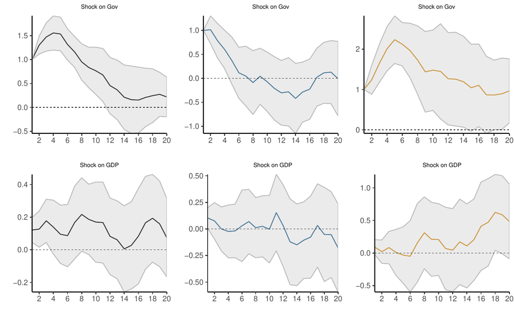

Figure 3: The figure replicates empirical results of Figure 12 from the supplementary appendix by Ramey and Zubairy (2018 35). The left column shows the (linear) reaction of government spending (first row) and GDP (second row) to a government spending shock. The middle column shows the reactions during periods of economic expansion and the right column during periods of economic slack.

```r
# --- Code to replicate parts of Figure 12 in the supplementary appendix by
# --- Ramey and Zubairy (2018, p.35)

# Load packages for creating plots
  library(gridExtra)
  library(ggpubr)

# Load data from package
  ag_data      <- ag_data
  sample_start <- 7
  sample_end   <- dim(ag_data)[1]

# Endogenous data
  endog_data <- ag_data[sample_start:sample_end,3:5]

# Shock variable
  shock      <- ag_data[sample_start:sample_end, 3]

# Estimate linear model
  results_lin_iv <- lp_lin_iv(endog_data = endog_data, lags_endog_lin = 4,
                    shock      = shock,      trend          = 0,
                    confint    = 1.96,       hor            = 20)

# Make and save linear plots
  iv_lin_plots <- plot_lin(results_lin_iv)

# Nonlinear shock (estimated by Ramey and Zubairy (2018))
  shock <- ag_data[sample_start:sample_end, 7]

# Use moving average growth rate of GDP as exogenous variable
  exog_data <- ag_data[sample_start:sample_end, 6]

# Use moving average growth rate of GDP as switching variable
  switching_variable <- ag_data$GDP_MA[sample_start:sample_end] - 0.8

# Estimate nonlinear model
  results_nl_iv <- lp_nl_iv(endog_data = endog_data, lags_endog_nl  = 3,
                            shock      = shock,      exog_data      = exog_data,
                            lags_exog  = 4,          trend          = 0,
                            confint    = 1.96,       hor            = 20,
                            switching  = switching_variable, use_hp = FALSE,
                            gamma      = 3)

# Make and save nonlinear plots
  plots_nl_iv <- plot_nl(results_nl_iv)

# Make list to save all plots
  combine_plots <- list()

# Save linear plots in list
  combine_plots[[1]] <- iv_lin_plots[[1]]
  combine_plots[[2]] <- iv_lin_plots[[3]]

# Save nonlinear plots for expansion period
  combine_plots[[3]] <- plots_nl_iv$gg_s1[[1]]
  combine_plots[[4]] <- plots_nl_iv$gg_s1[[3]]

# Save nonlinear plots for recession period
  combine_plots[[5]] <- plots_nl_iv$gg_s2[[1]]
  combine_plots[[6]] <- plots_nl_iv$gg_s2[[3]]

# Show all plots
  lin_plots_all      <- sapply(combine_plots, ggplotGrob)
  marrangeGrob(lin_plots_all, nrow = 2, ncol = 3, top = NULL)

# --- End example code
```

### 4.3 Estimating impulse responses for panel data

Using the *Jordà-Schularick-Taylor Macrohistory Database*, the following example estimates the impulse responses of the ratio of mortgage lending divided by the GDP to a 1% increase in the short-term interest rate. Observations during World Wars I and II and observations after 2013 are excluded.[^4] The empirical results are shown in Figure 4. An increase in the short-term interest rate leads to a decrease in the mortgage lending rate, whose effect attenuates after approximately 8 years.

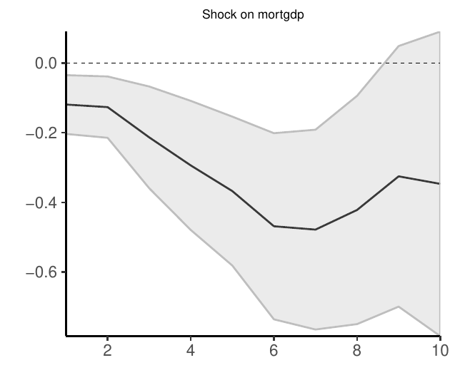

Figure 4: The figure shows the reaction of the ratio of mortgage lending divided by the GDP to a +1% change in the short-term interest rate.

```r
#--- Begin code for panel data

# Load libraries to download and read excel file from the website
  library(httr)
  library(readxl)
  library(dplyr)

# Retrieve the external JST Macrohistory Database
  url_jst <-"http://www.macrohistory.net/JST/JSTdatasetR3.xlsx"
  GET(url_jst, write_disk(jst_link <- tempfile(fileext = ".xlsx")))
  jst_data <- read_excel(jst_link, 2L)

# Remove observations after 2013 and swap the first two columns
  jst_data <- jst_data                      %>%
          dplyr::filter(year <= 2013)   %>%
          dplyr::select(country, year, everything())

# Prepare variables
  data_set <- jst_data                                       %>%
              mutate(stir    = stir)                         %>%
          mutate(mortgdp = 100*(tmort/gdp))              %>%
          mutate(hpreal  = hpnom/cpi)                    %>%
          group_by(country)                              %>%
          mutate(hpreal  = hpreal/hpreal[year==1990][1]) %>%
          mutate(lhpreal = log(hpreal))                  %>%

         mutate(lhpy    = lhpreal - log(rgdppc))        %>%
          mutate(lhpy    = lhpy - lhpy[year == 1990][1]) %>%
          mutate(lhpreal = 100*lhpreal)                  %>%
          mutate(lhpy    = 100*lhpy)                     %>%
          ungroup()                                      %>%

          mutate(lrgdp   = 100*log(rgdppc))              %>%
          mutate(lcpi    = 100*log(cpi))                 %>%
          mutate(lriy    = 100*log(iy*rgdppc))           %>%
          mutate(cay     = 100*(ca/gdp))                 %>%
          mutate(tnmort  = tloans - tmort)               %>%
          mutate(nmortgdp = 100*(tnmort/gdp))            %>%
          dplyr::select(country, year, mortgdp, stir, ltrate,
          lhpy, lrgdp, lcpi, lriy, cay, nmortgdp)


# Exclude observations from WWI and WWII
  data_sample <- seq(1870, 2016)[which(!(seq(1870, 2016) %in%
                                       c(seq(1914, 1918),
                                         seq(1939, 1947))))]

# Estimate linear panel model with robust covariance matrix
  results_panel <- lp_lin_panel(data_set  = data_set,  data_sample  = data_sample,
                        endog_data        = "mortgdp", cumul_mult   = TRUE,
                        shock             = "stir",    diff_shock   = TRUE,
                        panel_model       = "within",  panel_effect = "individual",
                        robust_cov        = "vcovSCC", c_exog_data  = "cay",
                        c_fd_exog_data    = colnames(data_set)[c(seq(4,9),11)],
                        l_fd_exog_data    = colnames(data_set)[c(seq(3,9),11)],
                        lags_fd_exog_data = 2,      confint      = 1.67,
                        hor               = 10)

# Show irfs
  plot(results_panel)

#--- End example
```

The following example uses the Hodrick–Prescott filter to decompose the log-GDP time series for each country to obtain the standardized variable $z_t$ for the logistic function in Eq. (5). Figure 5 shows the impulse responses for both regimes. The mortgage lending ratio declines in both regimes, although it is more pronounced during periods of economic expansion (left panel) than periods of economic slack (right panel).

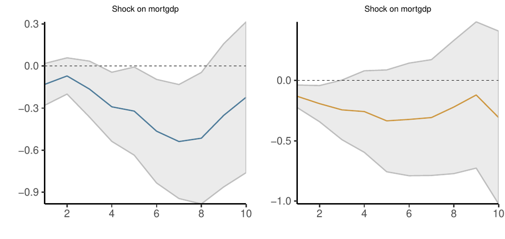

Figure 5: The figure shows the reaction of the ratio of mortgage lending divided by the GDP to a +1% change in the short-term interest rate during periods of economic expansions (left panel) and economic slack (right panel).

```r
# --- Begin example

# Estimate panel model
  results_panel <- lp_nl_panel(data_set   = data_set,  data_sample    = data_sample,
                        endog_data        = "mortgdp", cumul_mult     = TRUE,
                        shock             = "stir",    diff_shock     = TRUE,
                        panel_model       = "within",  panel_effect   = "individual",
                        robust_cov        = "vcovSCC", switching      = "lrgdp",
                        lag_switching     = TRUE,      use_hp         = TRUE,
                        lambda            = 6.25,      gamma          = 10,
                        c_exog_data       = "cay",
                        c_fd_exog_data    = colnames(data_set)[c(seq(4,9),11)],
                        l_fd_exog_data    = colnames(data_set)[c(seq(3,9),11)],
                        lags_fd_exog_data = 2,
                        confint           = 1.67,
                        hor               = 10)

# Show irfs
  plot(results_panel)


# --- End example
```

## 5 Summary

Since the 1980s, impulse response analysis has become a cornerstone in (macro-)econometrics. The traditional approach of recovering the impulse responses recursively from a (linear) VAR has been criticized due to some drawbacks, such as the imposed dynamics on the (economic) system, the curse of dimensionality, and the more difficult application to nonlinear frameworks.

The LPs by (Jordà 2005) have become a widely applied alternative to estimate impulse response functions. This paper introduced *lpirfs*, an R package that provides a broad framework for estimating and visualizing impulse response functions using LPs for a variety of data sets. I replicated the empirical results from the economic literature to prove the validity of the package and to show its usefulness for future research.

## 6 Appendix

This appendix contains a comparison between impulse responses estimated using the *vars* package and *lpirfs*. In addition, I conduct sensitivity analyses regarding the choices of $\gamma$ in Eq. (5) for the switching function and different values of $\lambda$ for the filter by (Hodrick and Prescott 1997). The code for all examples can be found in the `vignette` of *lpirfs*.

### 6.1 Comparison of impulse responses between *lpirfs* and *vars*

(Plagborg-Møller and Wolf 2019) showed that LPs and VARs compute the same impulse responses when the lag structure is unrestricted. For empirical studies, this implies that impulse responses that are estimated by LPs and SVARs are likely to agree at short horizons but differ at longer ones. To verify this implication, I compare the impulse responses estimated using the *lpirfs* and *vars* packages. The latter relies on the common SVAR approach.

Figure 6 shows the empirical results. The black lines and gray-shaded areas are the same as in Figure 1, which replicates Figure 5 in Jordà (2005 176). The orange lines and shaded areas correspond to impulse responses estimated by the *vars* package (i.e., a standard SVAR). The results show that impulse responses are similar up to that horizon, which equals the lag length $p$. For example, when the lag length $p$ equals $2$, the impulse responses and confidence intervals diverge very quickly (first column). When the lag length $p$ equals $6$, however, the impulse responses are much more similar. This finding coincides with the empirical results by (Plagborg-Møller and Wolf 2019), who compared the dynamic response of corporate bond spreads to a monetary policy shock.

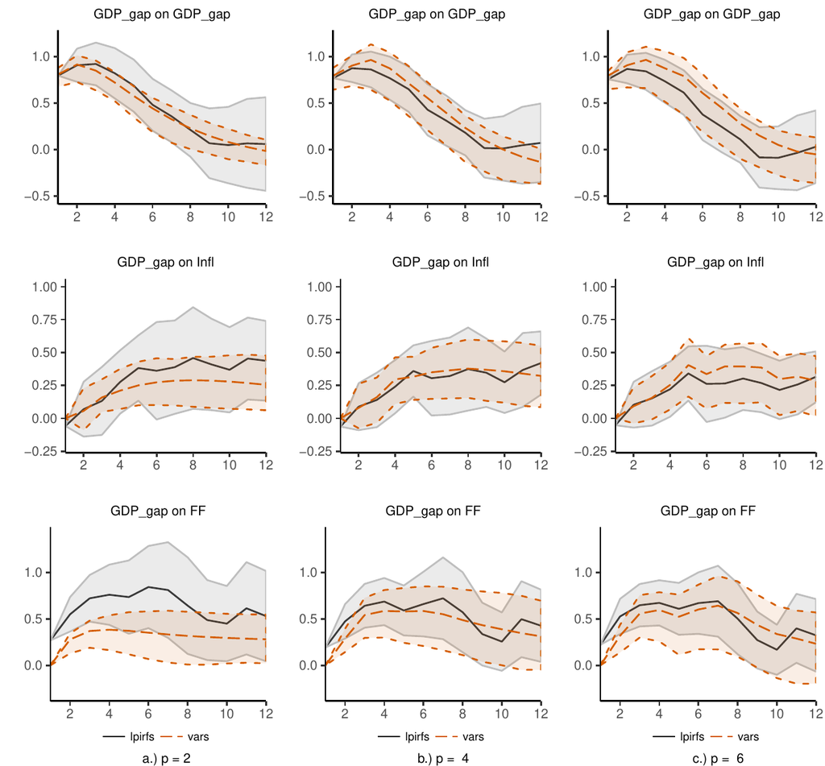

Figure 6: Comparison of impulse responses estimated by the packages *lpirfs* and *vars*. Each column shows the results for a fixed number of lags (i.e., $p$ = 2, 4, and 6). The shaded areas correspond to the 95% confidence intervals.

### 6.2 Sensitivity analyses for $\gamma$

The nonlinear functions in *lpirfs* allow separating the data into two regimes by either using a dummy approach or computing state probabilities with the logistic function given in Eq. (5). The logistic function depends on the parameter $\gamma$, which defines how sharply the two regimes are separated. To investigate how different choices of $\gamma$ might affect the results, I compare the nonlinear impulse responses for a shock of the federal funds rate on the output gap.

Figure 7 shows the empirical results. Each column corresponds to one choice of $\gamma$, namely $\gamma = 1, \ 5$, and $10$. I use the output gap as a switching variable and decompose it using the filter by (Hodrick and Prescott 1997). The penalty term $\lambda$ is set to $1 \ 600$ as suggested by (Ravn and Uhlig 2002). The first row of Figure 7 shows the evolution of the transition variable $F(z_t)$, along with NBER-dated recessions. By construction, a high value of the transition variable corresponds to a low output gap (i.e., periods of economic slack). Choosing a low value of $\gamma$ makes the regime-switching smooth, whereas higher values of $\gamma$ cause the switching to be quick. The second and third rows show nonlinear impulse responses for Regimes 1 (economic expansion) and 2 (economic recession). Although the choice of $\gamma$ has an effect on the results, it does not change the overall conclusion, namely that no “business-cycle” effects exist regarding the changes in the federal funds rate, which is in accordance with the findings by (Jordà 2005). At most, the effect would be very shortly negative during periods of economic downturn.

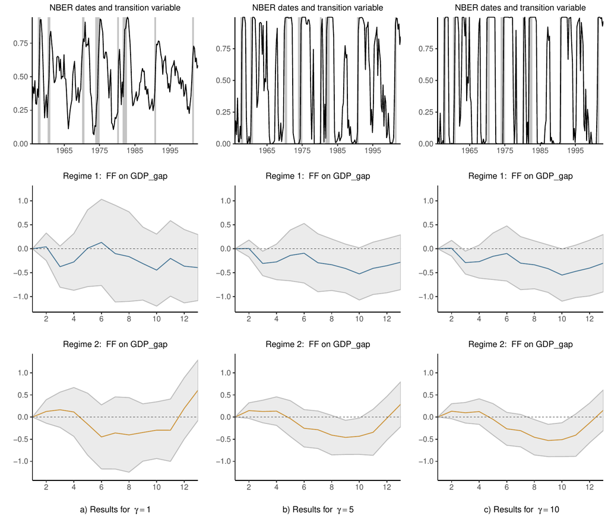

Figure 7: Comparison of nonlinear impulse responses for different values of $\gamma$. Each column shows the results for one parameter value (i.e., $\gamma = 1, 5,$ and $10$). The gray shaded areas in the first row correspond to NBER-dated recessions. The gray shaded areas in the second and third rows correspond to the 95% confidence intervals of the impulse responses.

### 6.3 Sensitivity analyses for $\lambda$

To use the switching function in Eq. (5), one must provide a standardized variable $z_t$. One option is to decompose a time series into a trend and a cyclical component using the filter by (Hodrick and Prescott 1997) (hereafter the HP-filter). *lpirfs* includes this option whose routine is written in *Rcpp*, making the computation very fast. If applied, the cyclical component of the HP-filter will be standardized and used for $z_t$. The filter depends on a penalty term $\lambda$, which must be given by the user. (Ravn and Uhlig 2002) argued that the parameter should be $6.25$ for annual data, $1 \ 600$ for quarterly data, and $129 \ 600$ for monthly data. To see how different choices of $\lambda$ influence the nonlinear impulse responses, I decompose the output gap for three different values of $\lambda$ and compare the results, which are shown in Figure 8. The value of $\gamma$ is fixed to $5$. The first row shows the cyclical component of the HP-filter along with the NBER-dated recessions. A low value in the cyclical component denotes periods of economic downturn. Note that the results of the second column in Figure 8 are identical to those in the second column of Figure 7. In contrast to the previous analysis, empirical results do change significantly, depending on the choice of $\lambda$. Thus, it is important to set the penalty term adequately.

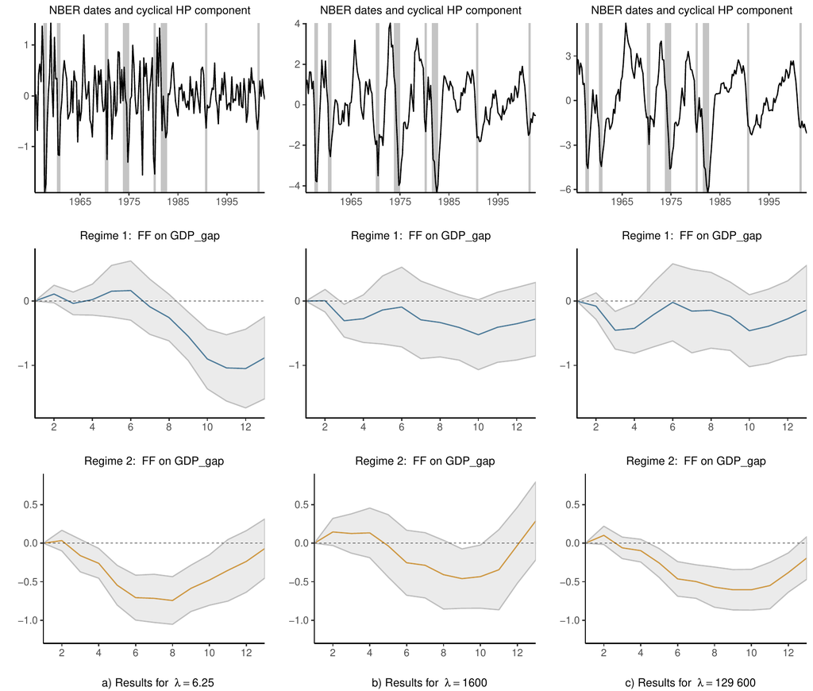

Figure 8: Comparison of nonlinear impulse responses with different values of $\lambda$ for the filter by (Hodrick and Prescott 1997). Each column shows the results for one parameter value (i.e., $\lambda = 6.25, 1\ 600,$ and $129\ 600$). The gray shaded areas in the first row correspond to NBER-dated recessions. The gray shaded areas in the second and third rows correspond to the 95% confidence intervals of the impulse responses.

## 7 Acknowledgement

I am grateful to the two anonymous reviewers, Philipp Wittenberg, Jon Danielsson, Rainer Schüssler, Tom Philipp Dybowski, and Detlef Steuer for their helpful comments and suggestions on the paper and package.

### 7.1 Supplementary materials

Supplementary materials are available in addition to this article. It can be downloaded at RJ-2019-052.zip

### 7.2 CRAN packages used

vars, lpirfs, Rcpp, plm

### 7.3 CRAN Task Views implied by cited packages

CausalInference, Econometrics, Finance, HighPerformanceComputing, MixedModels, NumericalMathematics, SpatioTemporal, TimeSeries

P. Adämmer. *lpirfs: Local projections impulse response functions.* 2019. URL https://CRAN.R-project.org/package=lpirfs. R package version: 0.1.6.

M. I. Ahmed and S. P. Cassou. Does consumer confidence affect durable goods spending during bad and good economic times equally? *Journal of Macroeconomics*, 50: 86–97, 2016. DOI https://doi.org/10.1016/j.jmacro.2016.08.008.

H. Akaike. A new look at the statistical model identification. *IEEE transactions on automatic control*, 19(6): 716–723, 1974. DOI https://doi.org/10.1109/TAC.1974.1100705.

D. W. K. Andrews and J. C. Monahan. An improved heteroskedasticity and autocorrelation consistent covariance matrix estimator. *Econometrica*, 60(4): 953–966, 1992. DOI https://doi.org/10.2307/2951574.

A. J. Auerbach and Y. Gorodnichenko. Measuring the output responses to fiscal policy. *American Economic Journal: Economic Policy*, 4(2): 1–27, 2012. DOI https://doi.org/10.1257/pol.4.2.1.

A. J. Auerbach and Y. Gorodnichenko. Output spillovers from fiscal policy. *American Economic Review*, 103(3): 141–46, 2013. DOI https://doi.org/10.1257/aer.103.3.141.

R. Barnichon and C. Brownlees. Impulse response estimation by smooth local projections. *Review of Economics and Statistics*, 101(3): 522–530, 2019. DOI https://doi.org/10.1162/rest_a_00778.

O. Blanchard and R. Perotti. An Empirical Characterization of the Dynamic Effects of Changes in Government Spending and Taxes on Output. *The Quarterly Journal of Economics*, 117(4): 1329–1368, 2002. DOI https://doi.org/10.1162/003355302320935043.

L. Brugnolini. About local projection impulse response function reliability. *CEIS Working Paper*, 2018. URL https://papers.ssrn.com/sol3/papers.cfm?abstract_id=3229218.

Y. Croissant and G. Millo. Panel data econometrics in R: The plm package. *Journal of Statistical Software*, 27(2): 1–43, 2008. DOI https://doi.org/10.18637/jss.v027.i02.

D. Eddelbuettel, R. François, J. Allaire, K. Ushey, Q. Kou, N. Russel, J. Chambers and D. Bates. Rcpp: Seamless r and c++ integration. *Journal of Statistical Software*, 40(8): 1–18, 2011. DOI https://doi.org/10.18637/jss.v040.i08.

G. Favara and J. Imbs. Credit supply and the price of housing. *American Economic Review*, 105(3): 958–92, 2015. DOI https://doi.org/10.1257/aer.20121416.

J. Garı́n, R. Lester and E. Sims. Are supply shocks contractionary at the ZLB? Evidence from utilization-adjusted TFP data. *Review of Economics and Statistics*, 101(1): 160–175, 2019. DOI https://doi.org/10.1162/rest_a_00723.

J. D. Hamilton. Nonlinearities and the macroeconomic effects of oil prices. *Macroeconomic Dynamics*, 15(S3): 364–378, 2011. DOI https://doi.org/10.1017/S1365100511000307.

R. J. Hodrick and E. C. Prescott. Postwar US business cycles: An empirical investigation. *Journal of Money, Credit, and Banking*, 1–16, 1997. DOI https://doi.org/10.2307/2953682.

C. M. Hurvich and C.-L. Tsai. Regression and time series model selection in small samples. *Biometrika*, 76(2): 297–307, 1989. DOI https://doi.org/10.1093/biomet/76.2.297.

Ò. Jordà. Estimation and inference of impulse responses by local projections. *American Economic Review*, 95(1): 161–182, 2005. DOI https://doi.org/10.1257/0002828053828518.

Ò. Jordà, M. Schularick and A. M. Taylor. Betting the house. *Journal of International Economics*, 96: S2–S18, 2015. DOI https://doi.org/10.1016/j.jinteco.2014.12.011.

Ò. Jordà, M. Schularick and A. M. Taylor. The effects of quasi-random monetary experiments. *Journal of Monetary Economics*, In press: 2019. DOI https://doi.org/10.1016/j.jmoneco.2019.01.021.

Ò. Jordà and A. M. Taylor. The time for austerity: Estimating the average treatment effect of fiscal policy. *The Economic Journal*, 126(590): 219–255, 2016. DOI https://doi.org/10.1111/ecoj.12332.

J. Keating. Structural approaches to vector autoregressions. *Federal Reserve Bank of St. Louis Review*, 74(September/October): 1992. URL https://files.stlouisfed.org/files/htdocs/publications/review/92/09/Vector_Sep_Oct1992.pdf.

L. Kilian and Y. J. Kim. How reliable are local projection estimators of impulse responses? *Review of Economics and Statistics*, 93(4): 1460–1466, 2011. DOI https://doi.org/10.1162/REST_a_00143.

W. K. Newey and K. D. West. Hypothesis testing with efficient method of moments estimation. *International Economic Review*, 777–787, 1987. DOI https://doi.org/10.2307/2526578.

M. T. Owyang, V. A. Ramey and S. Zubairy. Are government spending multipliers greater during periods of slack? Evidence from twentieth-century historical data. *American Economic Review*, 103(3): 129–134, 2013. DOI https://doi.org/10.1257/aer.103.3.129.

M. A. Petersen. Estimating standard errors in finance panel data sets: Comparing approaches. *The Review of Financial Studies*, 22(1): 435–480, 2009. DOI https://doi.org/10.1093/rfs/hhn053.

B. Pfaff. VAR, SVAR and SVEC models: Implementation Within R Package vars. *Journal of Statistical Software*, 27(4): 2008. DOI https://doi.org/10.18637/jss.v027.i04.

M. Plagborg-Møller and C. K. Wolf. Local projections and VARs estimate the same impulse responses. *Unpublished paper: Department of Economics, Princeton University*, 2019. URL https://scholar.princeton.edu/sites/default/files/mikkelpm/files/lp_var.pdf.

V. A. Ramey and S. Zubairy. Government spending multipliers in good times and in bad: Evidence from US historical data. *Journal of Political Economy*, 126(2): 850–901, 2018. DOI https://doi.org/10.1086/696277.

M. O. Ravn and H. Uhlig. On adjusting the hodrick-prescott filter for the frequency of observations. *Review of Economics and Statistics*, 84(2): 371–376, 2002. DOI https://doi.org/10.1162/003465302317411604.

G. Schwarz. Estimating the dimension of a model. *The Annals of Statistics*, 6(2): 461–464, 1978. DOI https://doi.org/10.1214/aos/1176344136.

C. A. Sims. Macroeconomics and reality. *Econometrica: Journal of the Econometric Society*, 1–48, 1980. DOI https://doi.org/10.2307/1912017.

E. T. Swanson. Measuring the effects of federal reserve forward guidance and asset purchases on financial markets. National Bureau of Economic Research. 2017. URL https://www.nber.org/papers/w23311.

S. Tenreyro and G. Thwaites. Pushing on a string: US monetary policy is less powerful in recessions. *American Economic Journal: Macroeconomics*, 8(4): 43–74, 2016. DOI https://doi.org/10.1257/mac.20150016.

[^1]: The appendix contains a comparison of impulse responses that are estimated using LPs and the traditional SVAR approach.
[^2]: The assumption of independent and identically distributed innovations is common in applied work but can be relaxed (Kilian and Kim 2011).
[^3]: In the appendix, I compare these results with those estimated by a general SVAR.
[^4]: *lpirfs* first computes all lags and lags of the first differences of the exogenous data. If the user wants to use a sub-sample (see example), the observations will be dropped after the lags have been constructed.